# convergence_rate slides

## Check the convergence rate of the MCMC chain

- given a proposal distrubtion:
  - our goal is to check that for a given proposal distribution, whether the acceptance rate would change with respect to change in in prior distribution, or it would be a constant
- given a prior distribution:
  - difference in acceptance rate with respect to change in proposal distribution
  - mcmc trace plot for different proposal distribution

```python
#  private val delta = 1.0
#  private val ahat = 20.0
#  private val bhat = 30.0
#  private val alpha1 = 4.0
#  private val alpha2 = 5.0
#  private val kappa = 1.0
#  private val scaleSigmaSquare: Double = 1.0
#  private val scalePhi: Double = 1.0
```

### δ checker

- changes the value of δ while keeping other parameters fixed; the scale parameters for $\sigma^2$ and $\phi$ are denoted as $\theta_{\sigma^2}$ and $\theta_{\phi}$, respectively
  - $\beta$ prior ~ Generalized Logistic distribution(20, 30)
  - $\sigma^2$ prior ~ Gamma(4.0, 1.0)
  - $\phi$ prior ~ Gamma(5.0, 1.0)
  - $\kappa$ = 1
  - $\theta_{\sigma^2}$ = 1.0
  - $\theta_{\phi}$ = 1.0

```python
import pandas as pd
```

```python
col_names = ['delta', 'acceptance_fraction']
accept_frac = pd.read_csv("/Users/danfengc/projects/unicorn/tests/data/mcmc_convergence_test_simple_data/acceptance_frac_delta.txt",
                         names = col_names,
                         sep = "\t")
```

- acception fraction for different values of $\delta$;

```python
accept_frac
```

|  | delta | acceptance_fraction |
| --- | --- | --- |
| 0 | 0.00001 | 0.1703 |
| 1 | 0.00010 | 0.1634 |
| 2 | 0.00100 | 0.1704 |
| 3 | 0.01000 | 0.1705 |
| 4 | 0.10000 | 0.1713 |
| 5 | 1.00000 | 0.1796 |
| 6 | 10.00000 | 0.1794 |
| 7 | 100.00000 | 0.1755 |

```python
col_names = ['beta']
beta_phi_100 = pd.read_csv('/Users/danfengc/projects/unicorn/tests/data/mcmc_convergence_test_simple_data/beta_phi_100.0.txt',
                          names = col_names)

beta_phi_1 = pd.read_csv('/Users/danfengc/projects/unicorn/tests/data/mcmc_convergence_test_simple_data/beta_phi_1.0.txt',
                          names = col_names)

beta_phi_10Eminus5 = pd.read_csv('/Users/danfengc/projects/unicorn/tests/data/mcmc_convergence_test_simple_data/beta_phi_1.0E-5.txt',
                          names = col_names)
```

```python
beta_phi_100 = beta_phi_100.reset_index()
beta_phi_1 = beta_phi_1.reset_index()
beta_phi_10Eminus5 = beta_phi_10Eminus5.reset_index()
```

```python
beta_phi_100_trimmed = beta_phi_100[beta_phi_100['index'] % 20 == 0]
beta_phi_1_trimmed = beta_phi_100[beta_phi_1['index'] % 20 == 0]
beta_phi_10Eminus5_trimmed = beta_phi_10Eminus5[beta_phi_10Eminus5['index'] % 20 == 0]
```

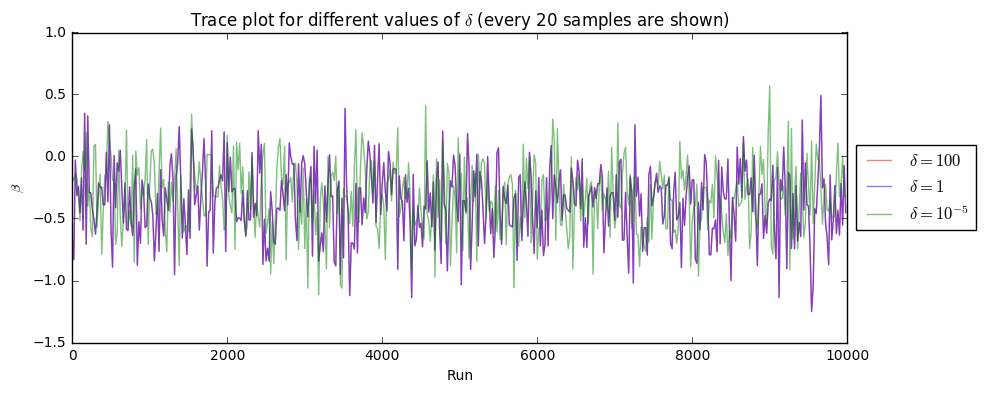

```python
import matplotlib.pyplot as plt
%matplotlib inline

#      plt.title(r'$\alpha > \beta$')

plt.figure(num=None,
           figsize=(10, 4),
           dpi=80,
           facecolor='w',
           edgecolor='k')

plt.plot(beta_phi_100_trimmed['beta'],
          color = 'red',
          alpha = 0.5,
          label = r'$\delta = 100$')

plt.plot(beta_phi_1_trimmed['beta'],
          color = 'blue',
          alpha = 0.5,
          label = r'$\delta = 1$')

plt.plot(beta_phi_10Eminus5_trimmed['beta'],
          color = 'green',
          alpha = 0.5,
          label = r'$\delta = 10^{-5}$')

plt.ylabel(r'$\beta$')
plt.xlabel("Run")

plt.legend(loc='center left', bbox_to_anchor=(1, 0.5))

plt.title(r'Trace plot for different values of $\delta$ (every 20 samples are shown)')

plt.savefig('/Users/danfengc/projects/unicorn/tests/unicorn-test/plots/trace_beta.pdf',
            figsize=(12, 4),
            dpi=80,
            bbox_inches='tight')
```

### scaleSigmaSquare checker

- changes the value of scaleSigmaSquare; while keeping other parameters fixed; the scale parameters for $\sigma^2$ and $\phi$ are denoted as $\theta_{\sigma^2}$ and $\theta_{\phi}$, respectively
  - $\beta$ prior ~ Generalized Logistic distribution(20, 30)
  - $\sigma^2$ prior ~ Gamma(4.0, 1.0)
  - $\phi$ prior ~ Gamma(5.0, 1.0)
  - $\kappa$ = 1
  - $\delta$ = 1.0
  - $\theta_{\phi}$ = 1.0

```python
col_names = ['scaleSigmaSquare', 'acceptance_fraction']
accept_frac = pd.read_csv("/Users/danfengc/projects/unicorn/tests/data/mcmc_convergence_test_simple_data/acceptance_frac_scaleSigmaSquare.txt",
                         names = col_names,
                         sep = "\t")
```

- acception fraction for different values of $\theta_{\sigma^2}$;

```python
accept_frac
```

|  | scaleSigmaSquare | acceptance_fraction |
| --- | --- | --- |
| 0 | 1 | 0.54705 |
| 1 | 2 | 0.44440 |
| 2 | 3 | 0.38610 |
| 3 | 4 | 0.31925 |
| 4 | 5 | 0.28770 |
| 5 | 6 | 0.28180 |
| 6 | 7 | 0.24480 |
| 7 | 8 | 0.23380 |
| 8 | 9 | 0.20310 |
| 9 | 10 | 0.20630 |

```python
col_names = ['sigmaSquare']
sigmaSquare_scaleSigmaSquare_1 = pd.read_csv('/Users/danfengc/projects/unicorn/tests/data/mcmc_convergence_test_simple_data/sigmaSquare_scaleSigmaSquare_1.txt',
                          names = col_names)

sigmaSquare_scaleSigmaSquare_5 = pd.read_csv('/Users/danfengc/projects/unicorn/tests/data/mcmc_convergence_test_simple_data/sigmaSquare_scaleSigmaSquare_5.txt',
                          names = col_names)

sigmaSquare_scaleSigmaSquare_10 = pd.read_csv('/Users/danfengc/projects/unicorn/tests/data/mcmc_convergence_test_simple_data/sigmaSquare_scaleSigmaSquare_10.txt',
                          names = col_names)
```

```python
sigmaSquare_scaleSigmaSquare_1 = sigmaSquare_scaleSigmaSquare_1.reset_index()
sigmaSquare_scaleSigmaSquare_5 = sigmaSquare_scaleSigmaSquare_5.reset_index()
sigmaSquare_scaleSigmaSquare_10 = sigmaSquare_scaleSigmaSquare_10.reset_index()
```

```python
sigmaSquare_scaleSigmaSquare_1_trimmed = sigmaSquare_scaleSigmaSquare_1[sigmaSquare_scaleSigmaSquare_1['index'] % 20 == 0]
sigmaSquare_scaleSigmaSquare_5_trimmed = sigmaSquare_scaleSigmaSquare_5[sigmaSquare_scaleSigmaSquare_5['index'] % 20 == 0]
sigmaSquare_scaleSigmaSquare_10_trimmed = sigmaSquare_scaleSigmaSquare_10[sigmaSquare_scaleSigmaSquare_10['index'] % 20 == 0]
```

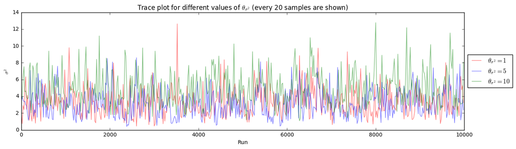

```python
plt.figure(num=None,
           figsize=(15, 4),
           dpi=80,
           facecolor='w',
           edgecolor='k')

plt.plot(sigmaSquare_scaleSigmaSquare_1_trimmed['sigmaSquare'],
          color = 'red',
          alpha = 0.5,
          label = r'$\theta_{\sigma^2} = 1$')

plt.plot(sigmaSquare_scaleSigmaSquare_5_trimmed['sigmaSquare'],
          color = 'blue',
          alpha = 0.5,
          label = r'$\theta_{\sigma^2} = 5$')

plt.plot(sigmaSquare_scaleSigmaSquare_10_trimmed['sigmaSquare'],
          color = 'green',
          alpha = 0.5,
          label = r'$\theta_{\sigma^2} = 10$')

plt.ylabel(r'$\sigma^2$')
plt.xlabel("Run")

plt.title(r'Trace plot for different values of $\theta_{\sigma^2}$ (every 20 samples are shown)')

plt.legend(loc='center left', bbox_to_anchor=(1, 0.5))

plt.savefig('/Users/danfengc/projects/unicorn/tests/unicorn-test/plots/trace_sigma_square.pdf',
            figsize=(15, 6),
            dpi=80,
            bbox_inches='tight')
```